# NEON ForestAGB — National Tree Aboveground Biomass Dataset

plant_scaling_data project

2026-05-02

# 1 Overview

**NEONForestAGB** (v2) is a derived data product that estimates individual tree aboveground biomass (AGB) for sites in the National Ecological Observatory Network (NEON). Tree diameters measured in the field are combined with published allometric equations to produce per-tree biomass estimates. The network spans the continental USA, Alaska, Puerto Rico, and Hawaii, covering a continental gradient of forest biomes.

> Atkins JW, Meier C, Alveshere B, Breland S, Langley M (2024). NEONForestAGBv2. figshare. Dataset. doi: 10.6084/m9.figshare.25625352.v1

> GitHub: atkinsjeff/NEONForestAGB Zenodo: doi: 10.5281/zenodo.11193519 License: CC0 1.0

**Underlying NEON data product:** > National Ecological Observatory Network. Woody plant vegetation structure > (DP1.10098.001). neonscience.org.

**Allometric methods:** > Chojnacky DC, Heath LS, Jenkins JC (2014). Updated generalized biomass > equations for North American tree species. *Forestry* 87:129–151. > > Jenkins JC, Chojnacky DC, Heath LS, Birdsey RA (2003). National-scale > biomass estimators for United States tree species. > *Forest Science* 49:12–35.

> **⚠ Citation note:** All DOIs and journal references above should be verified against Crossref before use in any manuscript. AGB values are model-derived (not from destructive harvest) and carry allometric uncertainty.

# 2 Top-level summary

```r
n_live <- sum(dat$plantStatus == "Live", na.rm = TRUE)

kable(data.frame(
  Metric = c(
    "Total measurement rows (all years)",
    "Unique individual trees",
    "Unique species (scientificName)",
    "Unique families",
    "NEON sites with biomass files (ingested)",
    "NEON sites in coordinate table (full network)",
    "Measurement years",
    "DBH range (cm)",
    "Height range (m)",
    "AGB range — Chojnacky (kg)",
    "AGB range — Jenkins (kg)",
    "Rows with live status",
    "Rows with stemDiameter",
    "Rows with height",
    "Rows with AGB (Chojnacky)",
    "Allometric methods",
    "License"
  ),
  Value = c(
    format(nrow(dat), big.mark = ","),
    format(length(unique(dat$individualID)), big.mark = ","),
    format(length(unique(dat$scientificName[!is.na(dat$scientificName)])),
           big.mark = ","),
    format(length(unique(dat$Family[!is.na(dat$Family)])), big.mark = ","),
    length(neon_sites),
    nrow(site_coords),
    paste0(min(dat$year, na.rm = TRUE), "\u20132023"),
    paste0(round(min(dat$stemDiameter, na.rm = TRUE), 1), "\u2013",
           round(max(dat$stemDiameter, na.rm = TRUE), 1)),
    paste0(round(min(dat$height, na.rm = TRUE), 1), "\u2013",
           round(max(dat$height, na.rm = TRUE), 1)),
    paste0(round(min(dat$AGBChojnacky, na.rm = TRUE), 2), "\u2013",
           format(round(max(dat$AGBChojnacky, na.rm = TRUE), 0), big.mark = ",")),
    paste0(round(min(dat$AGBJenkins, na.rm = TRUE), 2), "\u2013",
           format(round(max(dat$AGBJenkins, na.rm = TRUE), 0), big.mark = ",")),
    format(n_live, big.mark = ","),
    format(sum(!is.na(dat$stemDiameter)), big.mark = ","),
    format(sum(!is.na(dat$height)), big.mark = ","),
    format(sum(!is.na(dat$AGBChojnacky)), big.mark = ","),
    "Chojnacky et al. 2014; Jenkins et al. 2003",
    "CC0 1.0"
  ),
  stringsAsFactors = FALSE
), caption = "NEON ForestAGB top-level summary (23 ingested sites)")
```

NEON ForestAGB top-level summary (23 ingested sites)

| Metric | Value |
| --- | --- |
| Total measurement rows (all years) | 194,704 |
| Unique individual trees | 70,749 |
| Unique species (scientificName) | 374 |
| Unique families | 78 |
| NEON sites with biomass files (ingested) | 23 |
| NEON sites in coordinate table (full network) | 35 |
| Measurement years | 2014–2023 |
| DBH range (cm) | 0–187 |
| Height range (m) | 0.1–122 |
| AGB range — Chojnacky (kg) | 0–38,202 |
| AGB range — Jenkins (kg) | 0–39,077 |
| Rows with live status | 134,114 |
| Rows with stemDiameter | 145,167 |
| Rows with height | 178,432 |
| Rows with AGB (Chojnacky) | 117,994 |
| Allometric methods | Chojnacky et al. 2014; Jenkins et al. 2003 |
| License | CC0 1.0 |

# 3 Site map

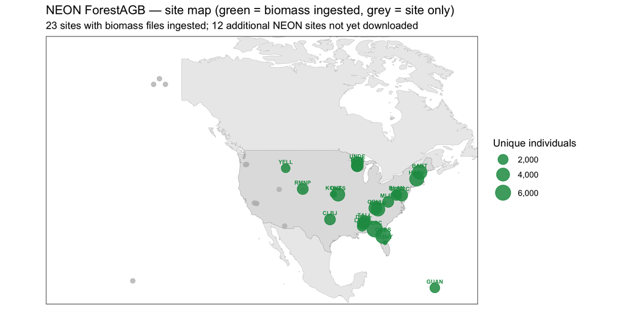

```r
sc <- site_coords |>
  filter(!is.na(X), !is.na(Y)) |>
  mutate(ingested = siteID %in% neon_sites)

site_n <- dat |>
  group_by(siteID) |>
  summarise(n_rows = n(), n_indiv = length(unique(individualID)), .groups = "drop")

sc <- sc |> left_join(site_n, by = "siteID")

world <- map_data("world")
usa   <- map_data("usa")

ggplot() +
  geom_polygon(data = world |> filter(region %in% c("Canada","Mexico")),
               aes(x = long, y = lat, group = group),
               fill = "grey92", color = "grey75", linewidth = 0.15) +
  geom_polygon(data = usa,
               aes(x = long, y = lat, group = group),
               fill = "grey88", color = "grey70", linewidth = 0.2) +
  geom_point(data = sc |> filter(!ingested),
             aes(x = X, y = Y), color = "#bdbdbd", size = 2.5, alpha = 0.8) +
  geom_point(data = sc |> filter(ingested),
             aes(x = X, y = Y, size = n_indiv),
             color = "#1a9850", alpha = 0.85) +
  geom_text(data = sc |> filter(ingested),
            aes(x = X, y = Y, label = siteID),
            size = 2.5, vjust = -1.1, fontface = "bold", color = "#1a9850") +
  scale_size_continuous(range = c(2, 9), labels = comma,
                        name = "Unique individuals") +
  coord_fixed(1.3, xlim = c(-175, -60), ylim = c(17, 72)) +
  labs(
    title = "NEON ForestAGB \u2014 site map (green = biomass ingested, grey = site only)",
    subtitle = paste0(length(neon_sites), " sites with biomass files ingested; ",
                      nrow(sc) - length(neon_sites),
                      " additional NEON sites not yet downloaded"),
    x = NULL, y = NULL
  ) +
  theme(axis.text = element_blank(), axis.ticks = element_blank(),
        panel.grid = element_blank(), legend.position = "right")
```

# 4 Per-site record counts

```r
per_site <- dat |>
  group_by(siteID) |>
  summarise(
    Domain      = first(domainID),
    N_rows      = n(),
    N_indiv     = length(unique(individualID)),
    N_species   = length(unique(scientificName[!is.na(scientificName)])),
    Yr_range    = paste0(min(year, na.rm=TRUE), "\u2013", max(year, na.rm=TRUE)),
    DBH_max_cm  = round(max(stemDiameter, na.rm=TRUE), 1),
    Ht_max_m    = round(max(height, na.rm=TRUE), 1),
    AGB_max_kg  = round(max(AGBChojnacky, na.rm=TRUE), 0),
    .groups = "drop"
  ) |>
  arrange(desc(N_rows))

kable(per_site,
      col.names = c("Site","Domain","N rows","N individuals","N species",
                    "Year range","Max DBH (cm)","Max Ht (m)","Max AGB Chojnacky (kg)"),
      caption   = "NEON ForestAGB per-site breakdown")
```

NEON ForestAGB per-site breakdown

| Site | Domain | N rows | N individuals | N species | Year range | Max DBH (cm) | Max Ht (m) | Max AGB Chojnacky (kg) |
| --- | --- | --- | --- | --- | --- | --- | --- | --- |
| BART | D01 | 19196 | 5173 | 34 | 2015–2023 | 119.8 | 119.8 | 12330 |
| HARV | D01 | 17597 | 5070 | 51 | 2014–2023 | 78.6 | 89.7 | 5340 |
| JERC | D03 | 13014 | 6408 | 71 | 2015–2022 | 76.2 | 102.7 | 4533 |
| ORNL | D07 | 11965 | 4007 | 66 | 2015–2023 | 86.2 | 40.3 | 7612 |
| GRSM | D07 | 11004 | 4502 | 73 | 2015–2022 | 120.0 | 44.1 | 11111 |
| UKFS | D06 | 10718 | 4304 | 41 | 2015–2022 | 187.0 | 30.0 | 33271 |
| OSBS | D03 | 10619 | 5815 | 37 | 2014–2022 | 66.6 | 31.3 | 3169 |
| SERC | D02 | 10312 | 3123 | 50 | 2015–2023 | 114.0 | 43.4 | 13234 |
| UNDE | D05 | 10161 | 3180 | 39 | 2016–2022 | 115.4 | 27.5 | 6891 |
| STEI | D05 | 9601 | 3124 | 46 | 2015–2022 | 68.4 | 29.1 | 3803 |
| DELA | D08 | 9406 | 3294 | 75 | 2015–2022 | 116.9 | 42.2 | 14071 |
| TREE | D05 | 8973 | 2866 | 40 | 2015–2022 | 68.3 | 29.1 | 2600 |
| MLBS | D07 | 8555 | 2554 | 39 | 2015–2022 | 83.4 | 39.3 | 4936 |
| TALL | D08 | 7715 | 3022 | 74 | 2015–2023 | 85.3 | 85.6 | 6101 |
| RMNP | D10 | 7462 | 2540 | 10 | 2017–2022 | 52.8 | 25.0 | 1312 |
| CLBJ | D11 | 6281 | 2478 | 34 | 2016–2022 | 57.9 | 65.0 | 2532 |
| SCBI | D02 | 5739 | 2272 | 46 | 2015–2022 | 117.5 | 43.2 | 11750 |
| LENO | D08 | 5291 | 1816 | 56 | 2015–2022 | 176.0 | 47.6 | 38202 |
| GUAN | D04 | 4586 | 1843 | 56 | 2015–2023 | 71.2 | 61.1 | -Inf |
| YELL | D12 | 2985 | 1359 | 10 | 2018–2023 | 139.0 | 122.0 | 18049 |
| BLAN | D02 | 2413 | 1179 | 42 | 2015–2023 | 77.6 | 35.7 | 4296 |
| KONZ | D06 | 812 | 578 | 21 | 2015–2022 | 47.1 | 11.7 | 1530 |
| DSNY | D03 | 299 | 244 | 16 | 2014–2022 | 61.0 | 26.8 | 2876 |

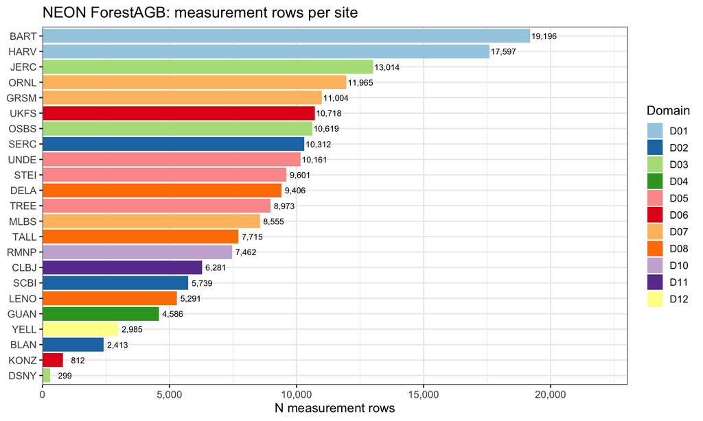

```r
ggplot(per_site, aes(x = reorder(siteID, N_rows), y = N_rows, fill = Domain)) +
  geom_col() +
  geom_text(aes(label = format(N_rows, big.mark=",")),
            hjust = -0.05, size = 3) +
  coord_flip() +
  scale_y_continuous(labels = comma, expand = expansion(mult = c(0, 0.2))) +
  scale_fill_brewer(palette = "Paired") +
  labs(x = NULL, y = "N measurement rows",
       title = "NEON ForestAGB: measurement rows per site",
       fill = "Domain")
```

# 5 Stem diameter distribution

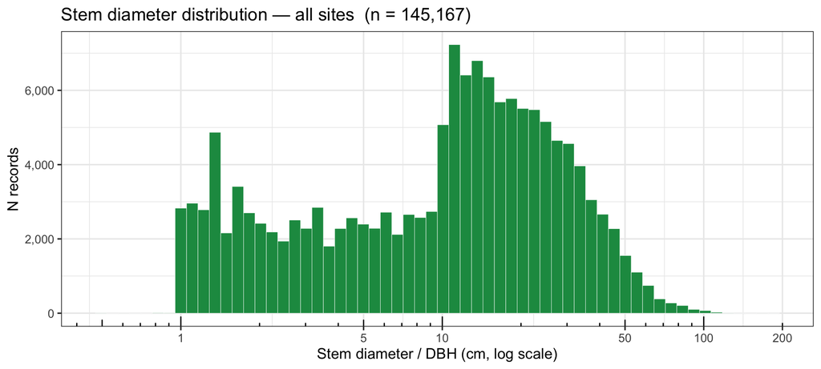

```r
dat |>
  filter(!is.na(stemDiameter), stemDiameter > 0) |>
  ggplot(aes(x = stemDiameter)) +
  geom_histogram(bins = 60, fill = "#1a9850", color = "white", linewidth = 0.15) +
  scale_x_log10(labels = comma, breaks = c(1, 5, 10, 50, 100, 200)) +
  scale_y_continuous(labels = comma) +
  annotation_logticks(sides = "b") +
  labs(
    x = "Stem diameter / DBH (cm, log scale)", y = "N records",
    title = paste0("Stem diameter distribution \u2014 all sites  (n = ",
                   format(sum(!is.na(dat$stemDiameter)), big.mark=","), ")")
  )
```

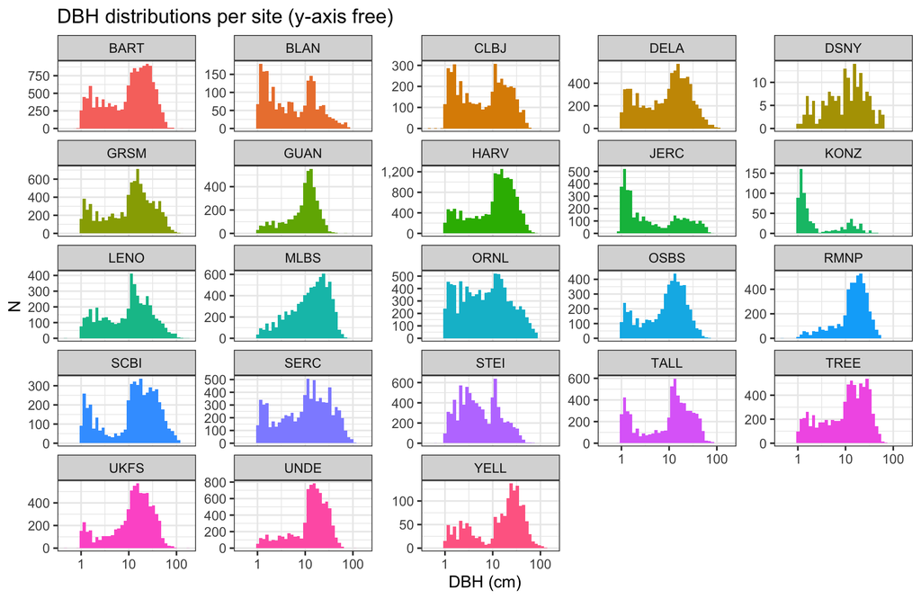

```r
dat |>
  filter(!is.na(stemDiameter), stemDiameter > 0) |>
  ggplot(aes(x = stemDiameter, fill = siteID)) +
  geom_histogram(bins = 40, show.legend = FALSE) +
  scale_x_log10(labels = comma) +
  scale_y_continuous(labels = comma) +
  facet_wrap(~ siteID, scales = "free_y", ncol = 5) +
  labs(x = "DBH (cm)", y = "N",
       title = "DBH distributions per site (y-axis free)")
```

# 6 Height distribution

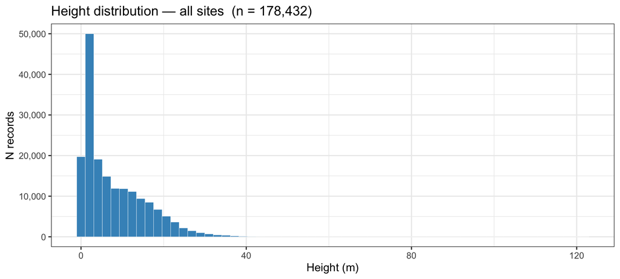

```r
dat |>
  filter(!is.na(height), height > 0) |>
  ggplot(aes(x = height)) +
  geom_histogram(bins = 60, fill = "#4393c3", color = "white", linewidth = 0.15) +
  scale_y_continuous(labels = comma) +
  labs(
    x = "Height (m)", y = "N records",
    title = paste0("Height distribution \u2014 all sites  (n = ",
                   format(sum(!is.na(dat$height)), big.mark=","), ")")
  )
```

# 7 Height ~ DBH scaling

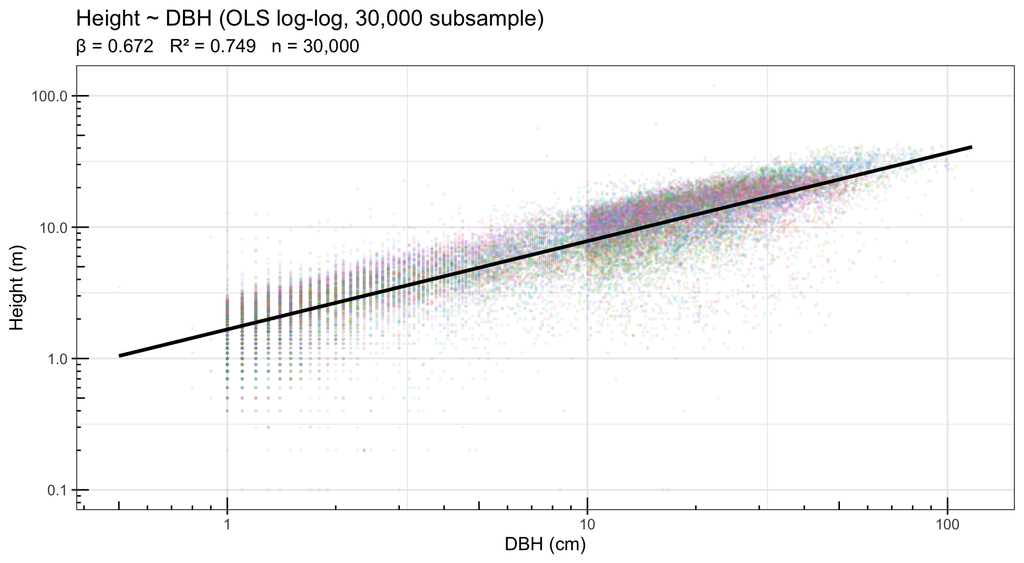

```r
sub <- dat |>
  filter(!is.na(stemDiameter), !is.na(height),
         stemDiameter > 0, height > 0) |>
  sample_n(min(30000, n()))

lm_fit <- lm(log(height) ~ log(stemDiameter), data = sub)
beta_hdbh <- round(coef(lm_fit)[2], 3)
r2_hdbh   <- round(summary(lm_fit)$r.squared, 3)

sub |>
  ggplot(aes(x = stemDiameter, y = height, color = siteID)) +
  geom_point(alpha = 0.08, size = 0.5, show.legend = FALSE) +
  geom_smooth(method = "lm", formula = y ~ x,
              color = "black", linewidth = 1.2, se = TRUE,
              aes(group = 1)) +
  scale_x_log10(labels = comma) + scale_y_log10(labels = comma) +
  annotation_logticks() +
  labs(
    x = "DBH (cm)", y = "Height (m)",
    title = "Height ~ DBH (OLS log-log, 30,000 subsample)",
    subtitle = paste0("\u03b2 = ", beta_hdbh, "   R\u00b2 = ", r2_hdbh,
                      "   n = 30,000")
  )
```

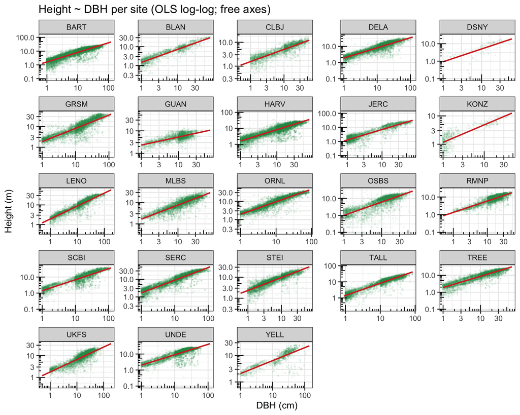

```r
dat |>
  filter(!is.na(stemDiameter), !is.na(height),
         stemDiameter > 0, height > 0) |>
  ggplot(aes(x = stemDiameter, y = height)) +
  geom_point(alpha = 0.06, size = 0.4, color = "#1a9850") +
  geom_smooth(method = "lm", formula = y ~ x,
              color = "#d73027", linewidth = 0.9, se = FALSE) +
  scale_x_log10(labels = comma) + scale_y_log10(labels = comma) +
  annotation_logticks() +
  facet_wrap(~ siteID, scales = "free", ncol = 5) +
  labs(x = "DBH (cm)", y = "Height (m)",
       title = "Height ~ DBH per site (OLS log-log; free axes)")
```

# 8 Per-site scaling exponents

```r
site_exp <- dat |>
  filter(!is.na(stemDiameter), !is.na(height), stemDiameter > 0, height > 0) |>
  group_by(siteID) |>
  filter(n() >= 20) |>
  summarise(
    n      = n(),
    beta   = round(coef(lm(log(height) ~ log(stemDiameter)))[2], 3),
    R2     = round(summary(lm(log(height) ~ log(stemDiameter)))$r.squared, 3),
    DBH_median = round(median(stemDiameter), 1),
    Ht_median  = round(median(height), 1),
    .groups = "drop"
  ) |>
  arrange(desc(n))

kable(site_exp,
      col.names = c("Site", "N", "\u03b2 (slope)", "R\u00b2",
                    "Median DBH (cm)", "Median Ht (m)"),
      caption = paste0(
        "OLS log-log Height ~ DBH scaling exponents per NEON site. ",
        "\u26a0 OLS underestimates slope; SMA regression preferred for formal inference."))
```

OLS log-log Height ~ DBH scaling exponents per NEON site. ⚠ OLS underestimates slope; SMA regression preferred for formal inference.

| Site | N | β (slope) | R² | Median DBH (cm) | Median Ht (m) |
| --- | --- | --- | --- | --- | --- |
| HARV | 14386 | 0.711 | 0.774 | 13.4 | 10.6 |
| BART | 13579 | 0.697 | 0.783 | 12.5 | 10.5 |
| ORNL | 8285 | 0.689 | 0.830 | 9.3 | 9.3 |
| DELA | 7973 | 0.629 | 0.797 | 10.9 | 7.8 |
| SERC | 7627 | 0.720 | 0.837 | 11.7 | 10.0 |
| STEI | 7315 | 0.613 | 0.774 | 4.7 | 6.6 |
| UNDE | 7203 | 0.651 | 0.650 | 15.3 | 13.1 |
| TREE | 7172 | 0.667 | 0.815 | 12.7 | 10.9 |
| GRSM | 6793 | 0.639 | 0.730 | 13.6 | 9.2 |
| MLBS | 6436 | 0.662 | 0.750 | 14.5 | 10.1 |
| TALL | 6363 | 0.758 | 0.873 | 12.6 | 10.9 |
| UKFS | 5471 | 0.572 | 0.719 | 14.7 | 8.4 |
| OSBS | 5220 | 0.785 | 0.625 | 10.6 | 7.1 |
| SCBI | 4892 | 0.687 | 0.769 | 15.7 | 9.0 |
| RMNP | 4742 | 0.642 | 0.713 | 16.2 | 8.2 |
| LENO | 4589 | 0.658 | 0.820 | 11.7 | 9.3 |
| JERC | 3820 | 0.743 | 0.786 | 2.5 | 2.8 |
| GUAN | 3356 | 0.357 | 0.475 | 11.2 | 5.2 |
| CLBJ | 3295 | 0.510 | 0.741 | 9.5 | 4.4 |
| BLAN | 2021 | 0.697 | 0.831 | 4.7 | 4.7 |
| YELL | 1475 | 0.489 | 0.665 | 20.8 | 8.3 |
| KONZ | 646 | 0.617 | 0.649 | 1.4 | 1.9 |
| DSNY | 158 | 0.734 | 0.547 | 10.8 | 5.6 |

# 9 Aboveground biomass (AGB) distributions

## 9.1 Chojnacky et al. 2014

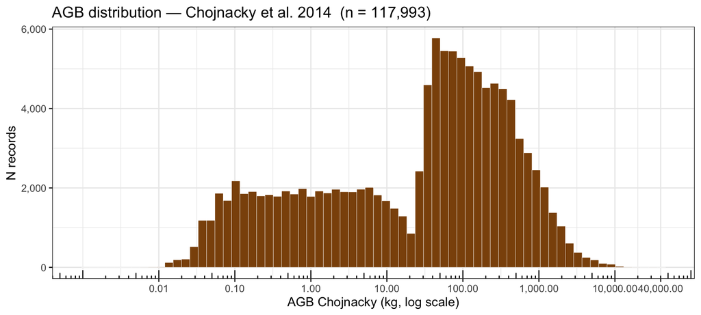

```r
dat |>
  filter(!is.na(AGBChojnacky), AGBChojnacky > 0) |>
  ggplot(aes(x = AGBChojnacky)) +
  geom_histogram(bins = 70, fill = "#8c510a", color = "white", linewidth = 0.15) +
  scale_x_log10(labels = comma,
                breaks = c(0.01, 0.1, 1, 10, 100, 1000, 10000, 40000)) +
  scale_y_continuous(labels = comma) +
  annotation_logticks(sides = "b") +
  labs(
    x = "AGB Chojnacky (kg, log scale)", y = "N records",
    title = paste0("AGB distribution \u2014 Chojnacky et al. 2014  (n = ",
                   format(sum(!is.na(dat$AGBChojnacky) & dat$AGBChojnacky > 0,
                              na.rm = TRUE), big.mark=","), ")")
  )
```

## 9.2 Jenkins et al. 2003

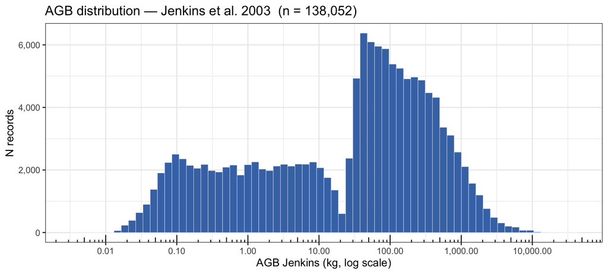

```r
dat |>
  filter(!is.na(AGBJenkins), AGBJenkins > 0) |>
  ggplot(aes(x = AGBJenkins)) +
  geom_histogram(bins = 70, fill = "#4575b4", color = "white", linewidth = 0.15) +
  scale_x_log10(labels = comma,
                breaks = c(0.01, 0.1, 1, 10, 100, 1000, 10000)) +
  scale_y_continuous(labels = comma) +
  annotation_logticks(sides = "b") +
  labs(
    x = "AGB Jenkins (kg, log scale)", y = "N records",
    title = paste0("AGB distribution \u2014 Jenkins et al. 2003  (n = ",
                   format(sum(!is.na(dat$AGBJenkins) & dat$AGBJenkins > 0,
                              na.rm = TRUE), big.mark=","), ")")
  )
```

## 9.3 AGB ~ DBH

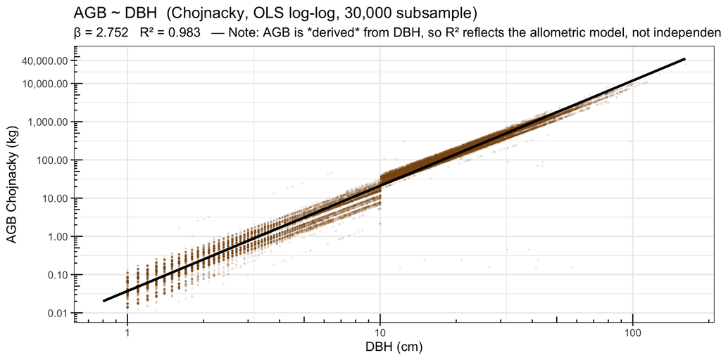

```r
sub_agb <- dat |>
  filter(!is.na(stemDiameter), !is.na(AGBChojnacky),
         stemDiameter > 0, AGBChojnacky > 0) |>
  sample_n(min(30000, n()))

lm_agb <- lm(log(AGBChojnacky) ~ log(stemDiameter), data = sub_agb)
beta_agb <- round(coef(lm_agb)[2], 3)
r2_agb   <- round(summary(lm_agb)$r.squared, 3)

sub_agb |>
  ggplot(aes(x = stemDiameter, y = AGBChojnacky)) +
  geom_point(alpha = 0.08, size = 0.5, color = "#8c510a") +
  geom_smooth(method = "lm", formula = y ~ x,
              color = "black", linewidth = 1.2, se = TRUE) +
  scale_x_log10(labels = comma) +
  scale_y_log10(labels = comma,
                breaks = c(0.01, 0.1, 1, 10, 100, 1000, 10000, 40000)) +
  annotation_logticks() +
  labs(
    x = "DBH (cm)", y = "AGB Chojnacky (kg)",
    title = "AGB ~ DBH  (Chojnacky, OLS log-log, 30,000 subsample)",
    subtitle = paste0("\u03b2 = ", beta_agb, "   R\u00b2 = ", r2_agb,
                      "   — Note: AGB is *derived* from DBH, so R\u00b2 reflects",
                      " the allometric model, not independent data")
  )
```

## 9.4 Chojnacky vs. Jenkins AGB comparison

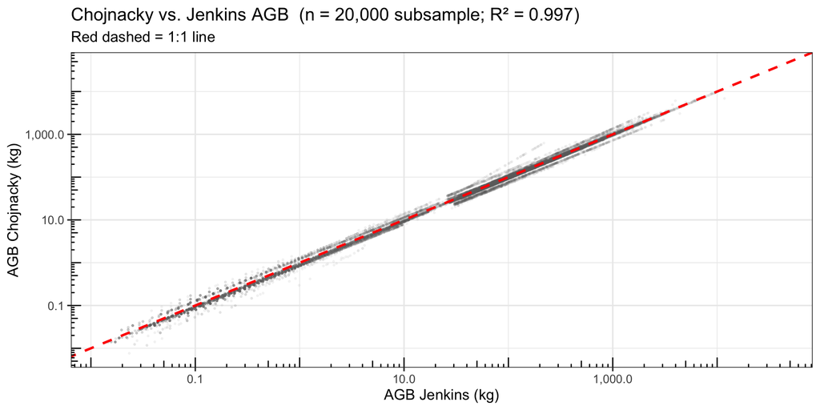

```r
sub_comp <- dat |>
  filter(!is.na(AGBChojnacky), !is.na(AGBJenkins),
         AGBChojnacky > 0, AGBJenkins > 0) |>
  sample_n(min(20000, n()))

lm_cv <- lm(log(AGBChojnacky) ~ log(AGBJenkins), data = sub_comp)
r2_cv <- round(summary(lm_cv)$r.squared, 3)

sub_comp |>
  ggplot(aes(x = AGBJenkins, y = AGBChojnacky)) +
  geom_point(alpha = 0.06, size = 0.5, color = "#666666") +
  geom_abline(slope = 1, intercept = 0, color = "red",
              linetype = "dashed", linewidth = 1) +
  scale_x_log10(labels = comma) + scale_y_log10(labels = comma) +
  annotation_logticks() +
  labs(
    x = "AGB Jenkins (kg)", y = "AGB Chojnacky (kg)",
    title = paste0("Chojnacky vs. Jenkins AGB  (n = 20,000 subsample; R\u00b2 = ",
                   r2_cv, ")"),
    subtitle = "Red dashed = 1:1 line"
  )
```

# 10 Plant status breakdown

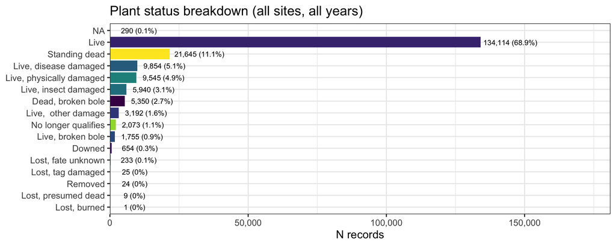

```r
dat |>
  count(plantStatus, sort = TRUE) |>
  mutate(pct = paste0(round(100 * n / sum(n), 1), "%")) |>
  ggplot(aes(x = reorder(plantStatus, n), y = n, fill = plantStatus)) +
  geom_col(show.legend = FALSE) +
  geom_text(aes(label = paste0(format(n, big.mark=","), " (", pct, ")")),
            hjust = -0.05, size = 3) +
  coord_flip() +
  scale_y_continuous(labels = comma, expand = expansion(mult = c(0, 0.35))) +
  scale_fill_viridis_d(option = "D") +
  labs(x = NULL, y = "N records",
       title = "Plant status breakdown (all sites, all years)")
```

# 11 Growth form breakdown

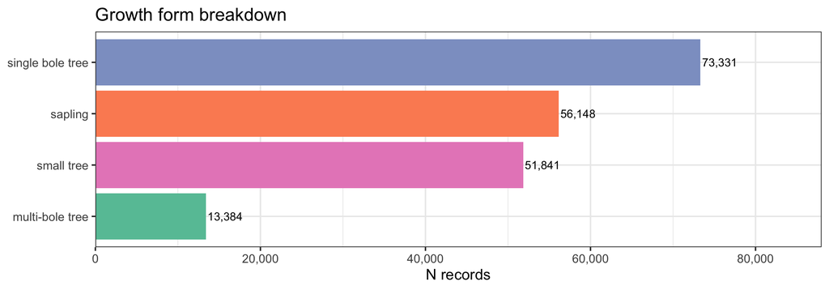

```r
dat |>
  count(growthForm, sort = TRUE) |>
  ggplot(aes(x = reorder(growthForm, n), y = n, fill = growthForm)) +
  geom_col(show.legend = FALSE) +
  geom_text(aes(label = format(n, big.mark=",")), hjust = -0.05, size = 3.5) +
  coord_flip() +
  scale_y_continuous(labels = comma, expand = expansion(mult = c(0, 0.2))) +
  scale_fill_brewer(palette = "Set2") +
  labs(x = NULL, y = "N records",
       title = "Growth form breakdown")
```

# 12 Taxonomic composition

## 12.1 Top 20 families

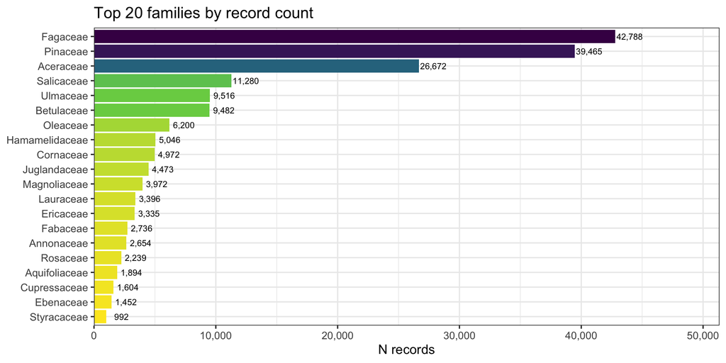

```r
dat |>
  filter(!is.na(Family)) |>
  count(Family, sort = TRUE) |>
  head(20) |>
  ggplot(aes(x = reorder(Family, n), y = n, fill = n)) +
  geom_col(show.legend = FALSE) +
  geom_text(aes(label = format(n, big.mark=",")), hjust = -0.05, size = 3) +
  coord_flip() +
  scale_y_continuous(labels = comma, expand = expansion(mult = c(0, 0.2))) +
  scale_fill_viridis_c(option = "D", direction = -1) +
  labs(x = NULL, y = "N records", title = "Top 20 families by record count")
```

## 12.2 Top 25 species

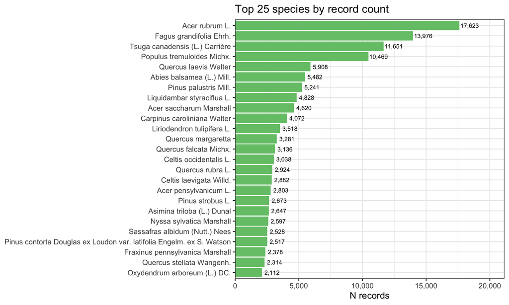

```r
dat |>
  filter(!is.na(scientificName)) |>
  count(scientificName, sort = TRUE) |>
  head(25) |>
  ggplot(aes(x = reorder(scientificName, n), y = n)) +
  geom_col(fill = "#74c476") +
  geom_text(aes(label = format(n, big.mark=",")), hjust = -0.05, size = 3) +
  coord_flip() +
  scale_y_continuous(labels = comma, expand = expansion(mult = c(0, 0.2))) +
  labs(x = NULL, y = "N records",
       title = "Top 25 species by record count")
```

# 13 Temporal coverage

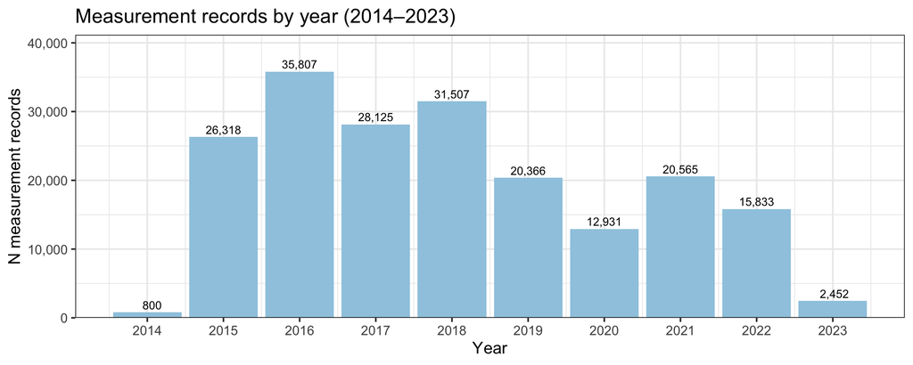

```r
dat |>
  count(year) |>
  ggplot(aes(x = year, y = n)) +
  geom_col(fill = "#9ecae1") +
  geom_text(aes(label = format(n, big.mark=",")), vjust = -0.4, size = 3.2) +
  scale_y_continuous(labels = comma, expand = expansion(mult = c(0, 0.15))) +
  scale_x_continuous(breaks = 2014:2023) +
  labs(x = "Year", y = "N measurement records",
       title = "Measurement records by year (2014\u20132023)")
```

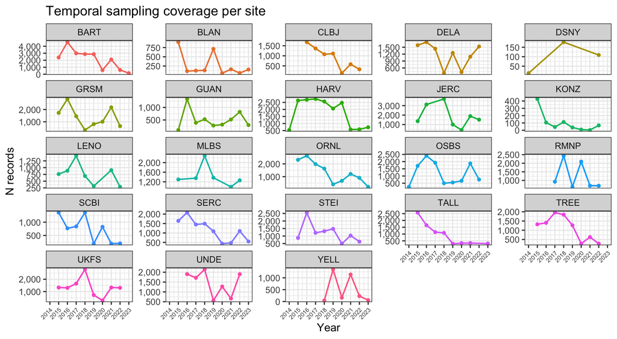

```r
dat |>
  count(siteID, year) |>
  ggplot(aes(x = year, y = n, color = siteID, group = siteID)) +
  geom_line(linewidth = 0.8) +
  geom_point(size = 1.5) +
  scale_y_continuous(labels = comma) +
  scale_x_continuous(breaks = 2014:2023) +
  facet_wrap(~ siteID, scales = "free_y", ncol = 5) +
  labs(x = "Year", y = "N records",
       title = "Temporal sampling coverage per site") +
  theme(legend.position = "none",
        axis.text.x = element_text(angle = 45, hjust = 1, size = 7))
```

# 14 Data completeness

```r
key_cols <- c("stemDiameter","height","AGBChojnacky","AGBJenkins",
              "AGBAnnighofer","scientificName","Family","plantStatus",
              "growthForm","year","siteID")

compl <- data.frame(
  Column = key_cols,
  N_nonNA = sapply(key_cols, function(c) sum(!is.na(dat[[c]]))),
  Pct     = paste0(
    sapply(key_cols, function(c)
      round(100 * mean(!is.na(dat[[c]])), 1)), "%")
)
kable(compl, caption = paste0(
  "Completeness for key columns (total rows = ",
  format(nrow(dat), big.mark = ","), ")"))
```

Completeness for key columns (total rows = 194,704)

|  | Column | N_nonNA | Pct |
| --- | --- | --- | --- |
| stemDiameter | stemDiameter | 145167 | 74.6% |
| height | height | 178432 | 91.6% |
| AGBChojnacky | AGBChojnacky | 117994 | 60.6% |
| AGBJenkins | AGBJenkins | 138054 | 70.9% |
| AGBAnnighofer | AGBAnnighofer | 26317 | 13.5% |
| scientificName | scientificName | 193492 | 99.4% |
| Family | Family | 192237 | 98.7% |
| plantStatus | plantStatus | 194414 | 99.9% |
| growthForm | growthForm | 194704 | 100% |
| year | year | 194704 | 100% |
| siteID | siteID | 194704 | 100% |

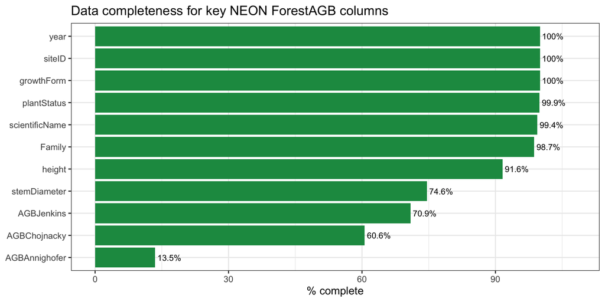

```r
compl |>
  mutate(pct_num = as.numeric(sub("%","",Pct))) |>
  ggplot(aes(x = reorder(Column, pct_num), y = pct_num)) +
  geom_col(fill = "#1a9850") +
  geom_text(aes(label = Pct), hjust = -0.1, size = 3.5) +
  coord_flip() +
  scale_y_continuous(limits = c(0, 108)) +
  labs(x = NULL, y = "% complete",
       title = "Data completeness for key NEON ForestAGB columns")
```

# 15 Allometric method summary

```r
kable(data.frame(
  Method = c("Chojnacky et al. 2014","Jenkins et al. 2003","Annighofer et al."),
  Column = c("AGBChojnacky","AGBJenkins","AGBAnnighofer"),
  N_nonNA = c(
    format(sum(!is.na(dat$AGBChojnacky)), big.mark=","),
    format(sum(!is.na(dat$AGBJenkins)),   big.mark=","),
    format(sum(!is.na(dat$AGBAnnighofer)),big.mark=",")
  ),
  Max_AGB_kg = c(
    format(round(max(dat$AGBChojnacky, na.rm=TRUE), 0), big.mark=","),
    format(round(max(dat$AGBJenkins,   na.rm=TRUE), 0), big.mark=","),
    format(round(max(dat$AGBAnnighofer,na.rm=TRUE), 0), big.mark=",")
  ),
  Scope = c(
    "North American species, FIA-based species groups",
    "National-scale, species-group equations",
    "Sapling-specific equations"
  ),
  stringsAsFactors = FALSE
), caption = "AGB allometric methods implemented in NEONForestAGB")
```

AGB allometric methods implemented in NEONForestAGB

| Method | Column | N_nonNA | Max_AGB_kg | Scope |
| --- | --- | --- | --- | --- |
| Chojnacky et al. 2014 | AGBChojnacky | 117,994 | 38,202 | North American species, FIA-based species groups |
| Jenkins et al. 2003 | AGBJenkins | 138,054 | 39,077 | National-scale, species-group equations |
| Annighofer et al. | AGBAnnighofer | 26,317 | 1,259 | Sapling-specific equations |

> **AGB is model-derived, not measured.** All biomass values are estimated from stem diameter using published allometric equations. They are NOT independent of DBH and should not be treated as direct measurements in allometric inference.

# 16 Master taxon list profile

```r
kable(data.frame(
  Metric = c("Total taxa in MasterTaxonList","Unique FIA codes",
             "Unique Jenkins model groups","Unique species groups (Chojnacky)"),
  Value  = c(
    format(nrow(taxon_list), big.mark=","),
    length(unique(taxon_list[["FIA.Code"]][!is.na(taxon_list[["FIA.Code"]])])),
    length(unique(taxon_list[["jenkins_model"]][!is.na(taxon_list[["jenkins_model"]])])),
    length(unique(taxon_list[["Species.Group"]][!is.na(taxon_list[["Species.Group"]])]))
  ),
  stringsAsFactors = FALSE
), caption = "MasterTaxonList.csv — allometric group assignments")
```

MasterTaxonList.csv — allometric group assignments

| Metric | Value |
| --- | --- |
| Total taxa in MasterTaxonList | 737 |
| Unique FIA codes | 312 |
| Unique Jenkins model groups | 10 |
| Unique species groups (Chojnacky) | 3 |

# 17 Notes for allometric merging

1. **AGB is model-derived:** `AGBChojnacky` and `AGBJenkins` are estimated from DBH using published equations — they are not independent of DBH and cannot be used as both predictor and response in the same regression.
2. **Repeated measurements:** The same `individualID` appears in multiple years. Longitudinal analyses must account for repeat visits (NEON typically revisits plots every 1–5 years).
3. **DBH units:** `stemDiameter` is in **cm** — compatible with BAAD, Tallo, and Nouragues. BAAD `d.bh` is in metres (×100) and ForestGEO Panama is in mm (÷10).
4. **Growth form mix:** `growthForm` includes single-bole trees, saplings, small trees, and multi-bole trees. Saplings and single-bole trees should be separated before fitting allometric models.
5. **Plant status:** Filter to `plantStatus == "Live"` for standard AGB estimation (134,114 of 194,704 records; 68.9%).
6. **Taxonomy:** `scientificName` uses USDA PLANTS conventions. Match to TNRS or GBIF before cross-source taxonomic merging.
7. **Geographic coordinates:** Not in the biomass CSV files. Site centroids are in `sitecoordinates.csv` (35 sites); plot-level coordinates are in the original NEON DP1.10098.001 data product.